# Live Session 6 Case Study Practice

Matthew Thacker and Damon Resnick

October 19, 2016

This is a live session assignment and practice for the Case Study Assignemnt I.

The goal is to learn more about reproducable research by getting and cleaning data, creating an RStudio project, and doing analysis with documentation that will help the researcher and other researchers in the future.

This project will include a README file, a data directory, an analysis directory, a paper directory, and a link to the an online repository in GitHub.

The data was taken from the Rolling Housing Sales for NYC:

http://www1.nyc.gov/home/search/index.page?search-terms=Rolling+sales+update

Our assignment was to look at the data for the borough of Manhattan.

The original code that this project is based off of was presented by the

#### Original Author: Benjamin Reddy

Taken from pages 49-50 of O’Neil and Schutt

require(gdata)

require(plyr) #Added by Monnie McGee

Install the gdata and plyr packages and set working directory in R.

```r
library(plyr)
library(gdata)
setwd("C:/Users/hp/Desktop/SMU/Doing Data Science/Live Classes/Unit 7")
```

.

You need a perl interpreter to load an xls file in Windows. It’s automatic in Mac mn <- read.xls(“rollingsales_brooklyn.xls”,pattern=“BOROUGH”)

So we will save the file as a csv and use read.csv instead:

```r
mn <- read.csv("./data/rollingsales_manhattan.csv",skip=4,header=TRUE)
```

.

#### Check the data:

```r
head(mn, 3)
```

```
##   BOROUGH              NEIGHBORHOOD
## 1       1 ALPHABET CITY
## 2       1 ALPHABET CITY
## 3       1 ALPHABET CITY
##                        BUILDING.CLASS.CATEGORY TAX.CLASS.AT.PRESENT BLOCK
## 1 01  ONE FAMILY DWELLINGS                                        1   390
## 2 03  THREE FAMILY DWELLINGS                                      1   376
## 3 07  RENTALS - WALKUP APARTMENTS                                2B   373
##   LOT EASE.MENT BUILDING.CLASS.AT.PRESENT
## 1  61        NA                        A4
## 2  24        NA                        C0
## 3  16        NA                        C1
##                                     ADDRESS APARTMENT.NUMBER ZIP.CODE
## 1 189 EAST 7TH   STREET                                         10009
## 2 264 EAST 7TH STREET                                           10009
## 3 326 EAST 4TH   STREET                                         10009
##   RESIDENTIAL.UNITS COMMERCIAL.UNITS TOTAL.UNITS LAND.SQUARE.FEET
## 1                 1                0           1             987
## 2                 3                0           3           2,059
## 3                10                0          10           2,204
##   GROSS.SQUARE.FEET YEAR.BUILT TAX.CLASS.AT.TIME.OF.SALE
## 1            2,183        1860                         1
## 2            3,696        1900                         1
## 3            8,625        1899                         2
##   BUILDING.CLASS.AT.TIME.OF.SALE   SALE.PRICE  SALE.DATE
## 1                             A4         -     9/23/2015
## 2                             C0   3,775,000  10/22/2015
## 3                             C1  20,000,000  11/17/2015
```

```r
tail(mn, 3)
```

```
##       BOROUGH              NEIGHBORHOOD
## 22801       1 WASHINGTON HEIGHTS UPPER
## 22802       1 WASHINGTON HEIGHTS UPPER
## 22803       1 WASHINGTON HEIGHTS UPPER
##                            BUILDING.CLASS.CATEGORY TAX.CLASS.AT.PRESENT
## 22801 44  CONDO PARKING                                               4
## 22802 44  CONDO PARKING                                               4
## 22803 44  CONDO PARKING                                               4
##       BLOCK  LOT EASE.MENT BUILDING.CLASS.AT.PRESENT
## 22801  2180 1215        NA                        RG
## 22802  2180 1216        NA                        RG
## 22803  2180 1216        NA                        RG
##                                         ADDRESS APARTMENT.NUMBER ZIP.CODE
## 22801 736 WEST 187 STREET                           PRK15           10033
## 22802 736 WEST 187TH STREET                         PRK16           10033
## 22803 736 WEST 187 STREET                           PRK16           10033
##       RESIDENTIAL.UNITS COMMERCIAL.UNITS TOTAL.UNITS LAND.SQUARE.FEET
## 22801                 0                0           1             -
## 22802                 0                0           1             -
## 22803                 0                0           1             -
##       GROSS.SQUARE.FEET YEAR.BUILT TAX.CLASS.AT.TIME.OF.SALE
## 22801              -          2003                         4
## 22802              -          2003                         4
## 22803              -          2003                         4
##       BUILDING.CLASS.AT.TIME.OF.SALE SALE.PRICE SALE.DATE
## 22801                             RG    42,000  10/7/2015
## 22802                             RG       -    5/20/2016
## 22803                             RG       -    1/29/2016
```

```r
summary(mn)
```

```
##     BOROUGH                     NEIGHBORHOOD
##  Min.   :1   MIDTOWN WEST             : 4718
##  1st Qu.:1   UPPER EAST SIDE (59-79)  : 2037
##  Median :1   UPPER EAST SIDE (79-96)  : 1671
##  Mean   :1   UPPER WEST SIDE (59-79)  : 1575
##  3rd Qu.:1   MIDTOWN EAST             : 1399
##  Max.   :1   UPPER WEST SIDE (79-96)  : 1034
##              (Other)                  :10369
##                                  BUILDING.CLASS.CATEGORY
##  13  CONDOS - ELEVATOR APARTMENTS            :7807
##  10  COOPS - ELEVATOR APARTMENTS             :6144
##  45  CONDO HOTELS                            :2504
##  26  OTHER HOTELS                            :1457
##  17  CONDO COOPS                             :1006
##  07  RENTALS - WALKUP APARTMENTS             : 783
##  (Other)                                     :3102
##  TAX.CLASS.AT.PRESENT     BLOCK           LOT         EASE.MENT
##  2      :16117        Min.   :   5   Min.   :   1.0   Mode:logical
##  4      : 5124        1st Qu.: 861   1st Qu.:  37.0   NA's:22803
##  2C     :  583        Median :1044   Median :1010.0
##  1      :  339        Mean   :1105   Mean   : 787.1
##  2B     :  276        3rd Qu.:1410   3rd Qu.:1302.0
##  2A     :  186        Max.   :2250   Max.   :9139.0
##  (Other):  178
##  BUILDING.CLASS.AT.PRESENT
##  R4     :7697
##  D4     :5914
##  RH     :2504
##  H3     :1440
##  R9     :1006
##  C6     : 762
##  (Other):3480
##                                       ADDRESS          APARTMENT.NUMBER
##  1335 AVENUE OF THE AMERIC                : 1777               :11549
##  102 WEST 57TH STREET                     : 1325   HU2         : 1236
##  1335 AVENUE OF THE AMER                  :  443   TIMES       :  987
##  200 EAST 94TH   STREET                   :  249   5A          :   87
##  50 RIVERSIDE BOULEVARD                   :  173   3A          :   86
##  301 WEST 53RD   STREET                   :  145   4A          :   78
##  (Other)                                  :18691   (Other)     : 8780
```

[output cut: 17 more lines]

```
##  Min.   :1.000             R4     :7807
##  1st Qu.:2.000             D4     :5914
##  Median :2.000             RH     :2504
##  Mean   :2.438             H3     :1441
##  3rd Qu.:2.000             R9     :1006
##  Max.   :4.000             C6     : 762
##                            (Other):3369
##        SALE.PRICE         SALE.DATE
##   -         : 4519   10/28/2015:  354
##   45,000    :  182   11/23/2015:  348
##   10        :   95   12/21/2015:  319
##   1,100,000 :   90   7/14/2016 :  286
##   850,000   :   88   1/13/2016 :  267
##   650,000   :   78   6/30/2016 :  255
##  (Other)    :17751   (Other)   :20974
```

```r
str(mn) # This is a very handy function in R! Displays the structure of an object.
```

```
## 'data.frame':    22803 obs. of  21 variables:
##  $ BOROUGH                       : int  1 1 1 1 1 1 1 1 1 1 ...
##  $ NEIGHBORHOOD                  : Factor w/ 39 levels "ALPHABET CITY            ",..: 1 1 1 1 1 1 1 1 1 1 ...
##  $ BUILDING.CLASS.CATEGORY       : Factor w/ 41 levels "01  ONE FAMILY DWELLINGS                    ",..: 1 3 5 5 5 5 5 5 5 5 ...
##  $ TAX.CLASS.AT.PRESENT          : Factor w/ 9 levels "  ","1","1A",..: 2 2 7 7 5 5 5 5 5 5 ...
##  $ BLOCK                         : int  390 376 373 373 377 377 385 387 387 387 ...
##  $ LOT                           : int  61 24 16 17 2 2 2 119 119 119 ...
##  $ EASE.MENT                     : logi  NA NA NA NA NA NA ...
##  $ BUILDING.CLASS.AT.PRESENT     : Factor w/ 122 levels "  ","A1","A4",..: 3 11 12 12 18 18 18 18 18 18 ...
##  $ ADDRESS                       : Factor w/ 11614 levels "1-2 RIVER TERRACE                        ",..: 3134 5488 6904 6922 732 732 3894 10437 10437 10433 ...
##  $ APARTMENT.NUMBER              : Factor w/ 2686 levels "            ",..: 1 1 1 1 1 1 1 1 1 1 ...
##  $ ZIP.CODE                      : int  10009 10009 10009 10009 10009 10009 10009 10009 10009 10009 ...
##  $ RESIDENTIAL.UNITS             : int  1 3 10 10 22 22 12 22 22 22 ...
##  $ COMMERCIAL.UNITS              : int  0 0 0 0 3 3 4 2 2 2 ...
##  $ TOTAL.UNITS                   : int  1 3 10 10 25 25 16 24 24 24 ...
##  $ LAND.SQUARE.FEET              : Factor w/ 1027 levels " -   "," 1,003 ",..: 1026 402 437 437 783 783 751 669 669 669 ...
##  $ GROSS.SQUARE.FEET             : Factor w/ 1457 levels " -   "," 1,000 ",..: 357 674 1332 1332 343 343 65 179 179 179 ...
##  $ YEAR.BUILT                    : int  1860 1900 1899 1900 1900 1900 1900 1920 1920 1920 ...
##  $ TAX.CLASS.AT.TIME.OF.SALE     : int  1 1 2 2 2 2 2 2 2 2 ...
##  $ BUILDING.CLASS.AT.TIME.OF.SALE: Factor w/ 121 levels "A1","A4","A5",..: 2 10 11 11 17 17 17 17 17 17 ...
##  $ SALE.PRICE                    : Factor w/ 6787 levels " -   "," 1 ",..: 1 3095 2464 1 1665 1 1 1215 1 1 ...
##  $ SALE.DATE                     : Factor w/ 350 levels "1/1/2016","1/10/2016",..: 336 45 70 70 322 322 152 122 122 122 ...
```

.

We then create a new variable that is a “clean” version of sale.price; we make sale.price.n numeric, not a factor.

#### This means that we replaced the -’s with NA and made a new column called SALE.PRICE.N so that R can deal with the data better.

The gsub() function is useful for finding and replacing characters. Counting the data use the count() function helps to tell how many numeric values and NAs there are in SALE.PRICE.N.

```r
mn$SALE.PRICE.N <- as.numeric(gsub("[^[:digit:]]","", mn$SALE.PRICE))
count(is.na(mn$SALE.PRICE.N))
```

```
##       x  freq
## 1 FALSE 18284
## 2  TRUE  4519
```

.

```r
names(mn) <- tolower(names(mn))
```

.

#### Get rid of leading digits

The frst 2 lines of the code below will again replace ‘-’ with NA in R so that missing data will not throw off the analysis.

```r
mn$gross.sqft <- as.numeric(gsub("[^[:digit:]]","", mn$gross.square.feet))
mn$land.sqft <- as.numeric(gsub("[^[:digit:]]","", mn$land.square.feet))
mn$year.built <- as.numeric(as.character(mn$year.built))
```

.

#### Here we do a bit of exploration to make sure there’s not anything weird going on with sale prices

Attaching ‘mn’ means that the commands after will automatically reference this data without needing to specify ‘mn’ for each command.

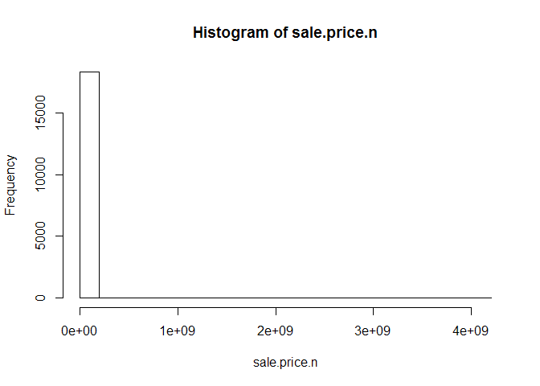

```r
attach(mn)
hist(sale.price.n) #Something is wrong! The histogram shows that most sales seem to be close to $0.
```

```r
detach(mn)
```

.

#### Keep only the actual sales

```r
mn.sale <- mn[mn$sale.price.n!=0,]
```

.

#### Create a scatterplot of the mn.sale data when compared to sq. footage.

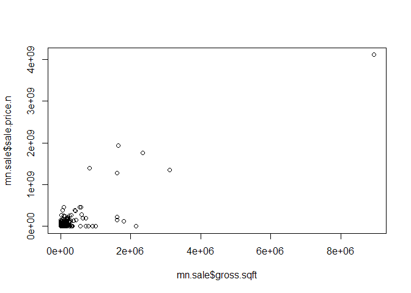

```r
plot(mn.sale$gross.sqft,mn.sale$sale.price.n)
```

.

#### Perform a log base 10 transformation of the data and create a new scatterplot.

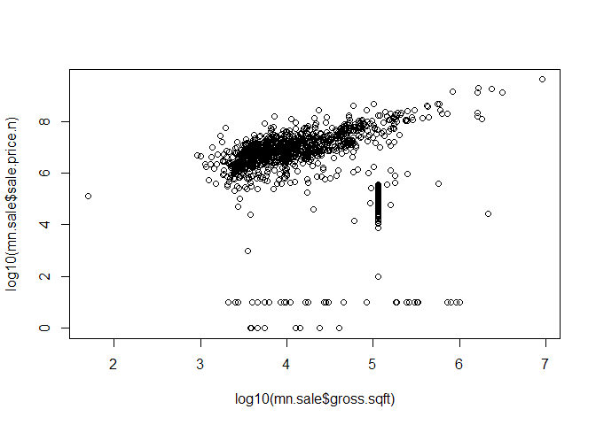

```r
plot(log10(mn.sale$gross.sqft),log10(mn.sale$sale.price.n))
```

.

#### Let’s look at 1, 2, and 3-family homes

This creates a new data table called mn.homes, which provides a list of family homes. It accomplishes this by searching for the term ‘family’ within mn.sale building class and passes it to mn.homes.

```r
mn.homes <- mn.sale[which(grepl("FAMILY",mn.sale$building.class.category)),]
```

.

Look at the dimensions for the mn.homes object (observations and variables)

```r
dim(mn.homes)
```

```
## [1] 225  24
```

.

#### Plot the log10 of sale.price vs. gross.sqft and look at the summary of sale.price

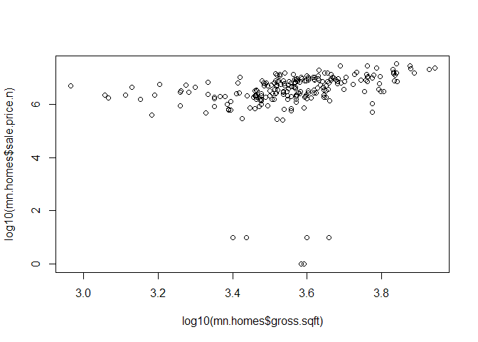

```r
plot(log10(mn.homes$gross.sqft),log10(mn.homes$sale.price.n))
```

```r
summary(mn.homes[which(mn.homes$sale.price.n<100000),])
```

```
##     borough                     neighborhood
##  Min.   :1   GREENWICH VILLAGE-WEST   :2
##  1st Qu.:1   GREENWICH VILLAGE-CENTRAL:1
##  Median :1   HARLEM-EAST              :1
##  Mean   :1   MIDTOWN EAST             :1
##  3rd Qu.:1   UPPER WEST SIDE (59-79)  :1
##  Max.   :1   ALPHABET CITY            :0
##              (Other)                  :0
##                                  building.class.category
##  01  ONE FAMILY DWELLINGS                    :2
##  02  TWO FAMILY DWELLINGS                    :2
##  03  THREE FAMILY DWELLINGS                  :2
##  04  TAX CLASS 1 CONDOS                      :0
##  07  RENTALS - WALKUP APARTMENTS             :0
##  08  RENTALS - ELEVATOR APARTMENTS           :0
##  (Other)                                     :0
##  tax.class.at.present     block             lot        ease.ment
##  1      :6            Min.   : 542.0   Min.   : 17.0   Mode:logical
##         :0            1st Qu.: 603.0   1st Qu.: 36.5   NA's:6
##  1A     :0            Median : 891.5   Median : 43.5
##  1C     :0            Mean   : 988.0   Mean   : 51.0
##  2      :0            3rd Qu.:1279.0   3rd Qu.: 47.5
##  2A     :0            Max.   :1688.0   Max.   :119.0
##  (Other):0
##  building.class.at.present                                      address
##  C0     :2                 109 MAC DOUGAL STREET                    :1
##  A4     :1                 129 WEST 78TH STREET                     :1
##  B3     :1                 22 CHRISTOPHER STREET                    :1
##  S1     :1                 234 EAST 49TH   STREET                   :1
##  S2     :1                 310 WEST 11 STREET                       :1
##         :0                 339 EAST 116 STREET                      :1
##  (Other):0                 (Other)                                  :0
##      apartment.number    zip.code     residential.units commercial.units
##              :6       Min.   :10012   Min.   :1.00      Min.   :0.0000
##  (-)         :0       1st Qu.:10014   1st Qu.:1.25      1st Qu.:0.0000
##  *           :0       Median :10016   Median :2.00      Median :0.0000
##  1           :0       Mean   :10018   Mean   :2.00      Mean   :0.3333
##  1-2W        :0       3rd Qu.:10022   3rd Qu.:2.75      3rd Qu.:0.7500
##  1-A         :0       Max.   :10029   Max.   :3.00      Max.   :1.0000
##  (Other)     :0
```

[output cut: 9 more lines]

```
##  Min.   :1                 C0     :2                       10        :4
##  1st Qu.:1                 A4     :1                       1         :2
##  Median :1                 B3     :1                       -         :0
##  Mean   :1                 S1     :1                       1,000     :0
##  3rd Qu.:1                 S2     :1                       1,000,000 :0
##  Max.   :1                 A1     :0                       1,000,391 :0
##                            (Other):0                      (Other)    :0
##       sale.date  sale.price.n     gross.sqft     land.sqft
##  6/28/2016 :2   Min.   : 1.00   Min.   :2520   Min.   :1235
##  12/14/2015:1   1st Qu.: 3.25   1st Qu.:3014   1st Qu.:1594
##  12/9/2015 :1   Median :10.00   Median :3871   Median :1726
##  8/9/2016  :1   Mean   : 7.00   Mean   :3588   Mean   :1886
##  9/9/2015  :1   3rd Qu.:10.00   3rd Qu.:3953   3rd Qu.:1885
##  1/1/2016  :0   Max.   :10.00   Max.   :4560   Max.   :3140
##  (Other)   :0
```

.

#### Remove outliers that seem like they weren’t actual sales and show the plot

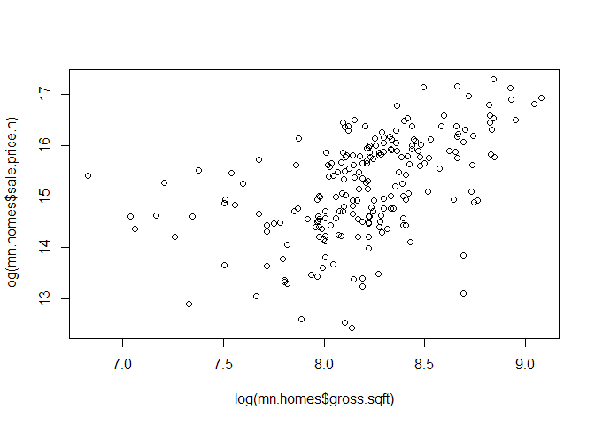

```r
mn.homes$outliers <- (log10(mn.homes$sale.price.n) <=5) + 0
mn.homes <- mn.homes[which(mn.homes$outliers==0),]
plot(log(mn.homes$gross.sqft),log(mn.homes$sale.price.n))
```

.

#### Create a .csv file called “cleaned_rollingsales_manhattan.csv” to save the cleaned data

```r
write.csv(mn.homes, "cleaned_rollingsales_manhattan.csv", row.names = TRUE)
```